# Item Response Theory

Erin M. Buchanan

2021-02-01

# Item Response Theory

- What do you do if you have dichotomous (or categorical) manifest variables?
  - Many agree that more than four response options can be treated as continuous without a loss in power or interpretation.
  - Do you treat these values as categorical?
- Do you assume the underlying latent variable is continuous?

# Categorical Options

- There are two approaches that allow us to analyze data with categorical predictors:
  - Item Factor Analysis
    - More traditional factor analysis approach using ordered responses
    - You can talk about item loading, eliminate bad questions, etc.
    - In the `lavaan` framework, you update your `cfa()` to include the `ordered` argument
  - Item Response Theory

# Item Response Theory

- Classical test theory is considered “true score theory”
  - Any differences in responses are differences in ability or underlying trait
  - CTT focuses on reliability and item correlation type analysis
  - Cannot separate the test and person characteristics
- IRT is considered more modern test theory focusing on the latent trait
  - Focuses on the item for *where* it measures a latent trait, discrimination, and guessing
  - Additionally, with more than two outcomes, we can examine ordering, response choice options, and more

# Issues

- Unidimensionality: assumption is that there is one underlying trait or dimension you are measuring
  - You can run separate models for each dimension
  - There are multitrait options for IRT
- Local Independence
  - After you control for the latent variable, the items are uncorrelated

# Item Response Theory

- A simple example of test versus person
  - 3 item questionnaire
  - Yes/no scaling
  - 8 response patterns
  - Four total scores (0, 1, 2, 3)

# Item Response Theory

- Item characteristic curves (ICCs)
  - The log probability curve of theta and the probability of a correct response

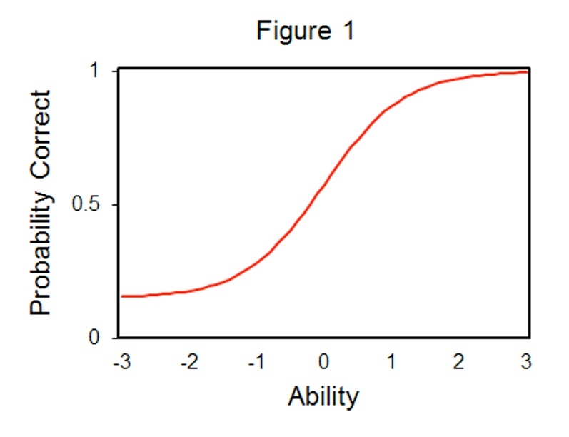

# Item Response Theory

- Theta – ability or the underlying latent variable score
- b – Item location – where the probability of getting an item correct is 50/50
  - Also considered where the item performs best
  - Can be thought of as item difficulty

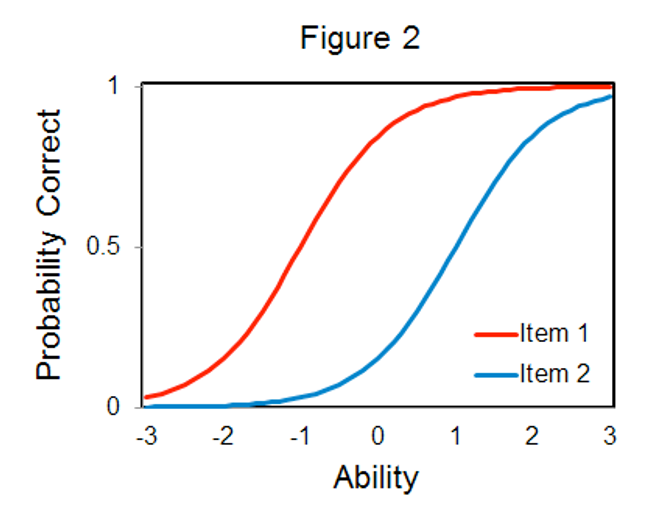

# Item Response Theory

- a – item discrimination
  - Tells you how well an item measures the latent variable
  - Larger a values indicate better items

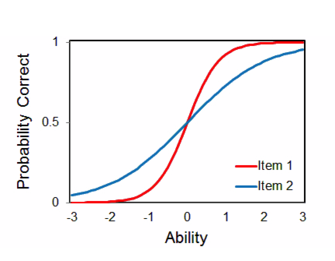

# Item Response Theory

- c – guessing parameter
  - The lower level likelihood of getting the item correct

[figure not shown]

# Item Response Theory

- 1 Parameter Logistic (1PL)
  - Also known as the Rasch Model
  - Only uses b
- 2 Parameter Logistic (2PL)
  - Uses b and a
- 3 Parameter Logistic (3PL)
  - Uses b, a, and c

# Polytomous IRT

- A large portion of IRT focuses on dichotomous data (yes/no, correct/incorrect)
- Scoring is easier because you have “right” and “wrong” answers
- Separately, polytomous IRT focuses on data with multiple answers, with no “right” answer
  - Focus on ordering, meaning that low scores represent lower abilities, while high scores are higher abilities
  - Likert type scales

# Polytomous IRT

- Couple of types of models:
  - Graded Response Model
  - Generalized Partial Credit Model
  - Partial Credit Model

# Polytomous IRT

- A graded response model is simplest but can be hard to fit.
- Takes the number of categories – 1 and creates mini 2PLs for each of those boundary points (1-rest, 2-rest, 3-rest, etc.).
- You get probabilities of scoring at this level OR higher

# Polytomous IRT

- The generalized partial credit and partial credit models account for the fact that you may not have each category used equally
- Therefore, you get the mini 2PLs for adjacent categories (1-2, 2-3, 3-4)
- If your categories are ordered (which you often want), these two estimations can be very similar.
- Another concern with the partial credit models is making sure that all categories have a point at which they are the most likely answer (thresholds)

# Polytomous IRT

- Install the `mirt()` library to use the multidimensional IRT package.
- We are not covering multiple dimensional or multigroup IRT, but this package can do those models or polytomous estimation.

# IRT Examples

- Let’s start with DIRT: Dichotomous IRT
- Dataset is the LSAT, which is scored as right or wrong

```r
library(ltm)
library(mirt)
data(LSAT)
head(LSAT)
```

```
##   Item 1 Item 2 Item 3 Item 4 Item 5
## 1      0      0      0      0      0
## 2      0      0      0      0      0
## 3      0      0      0      0      0
## 4      0      0      0      0      1
## 5      0      0      0      0      1
## 6      0      0      0      0      1
```

# Two Parameter Logistic

```r
# Data frame name ~ z1 for one latent variable
#irt.param to give it to you standardized
LSAT.model <- ltm(LSAT ~ z1,
                  IRT.param = TRUE)
```

# 2PL Output

- Difficulty = b = theta = ability
- Discrimination = a = how good the question is at figuring a person out.

```r
coef(LSAT.model)
```

```
##            Dffclt    Dscrmn
## Item 1 -3.3597341 0.8253715
## Item 2 -1.3696497 0.7229499
## Item 3 -0.2798983 0.8904748
## Item 4 -1.8659189 0.6885502
## Item 5 -3.1235725 0.6574516
```

# 2PL Plots

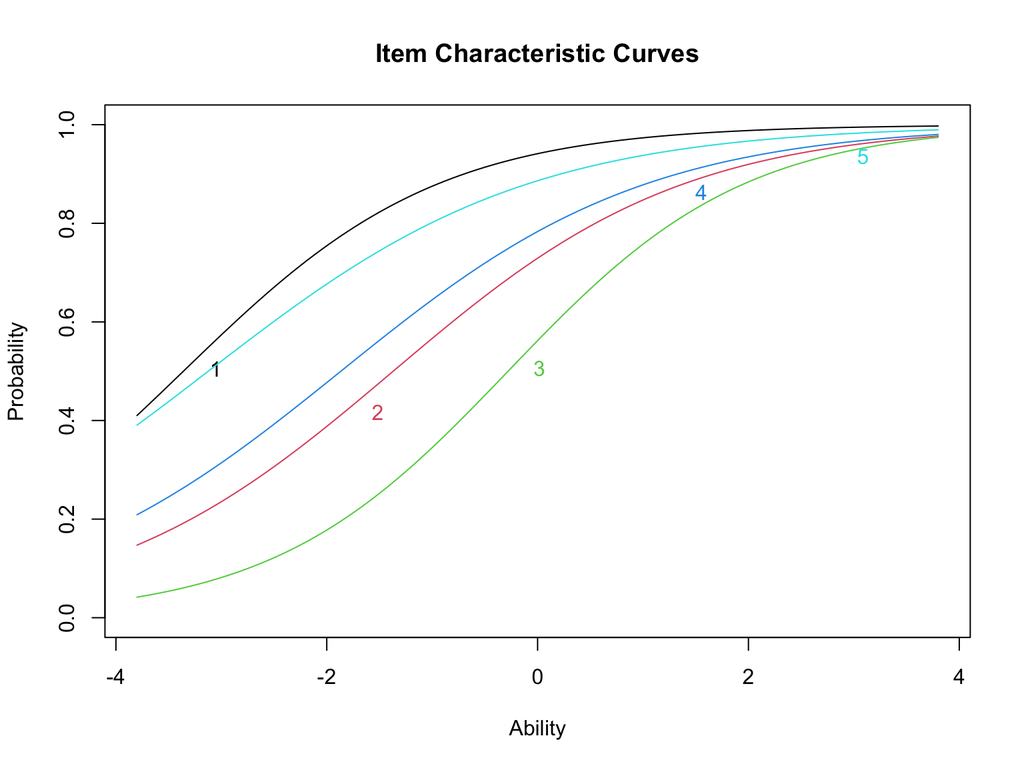

```r
plot(LSAT.model, type = "ICC") ## all items at once
```

# 2PL Plots

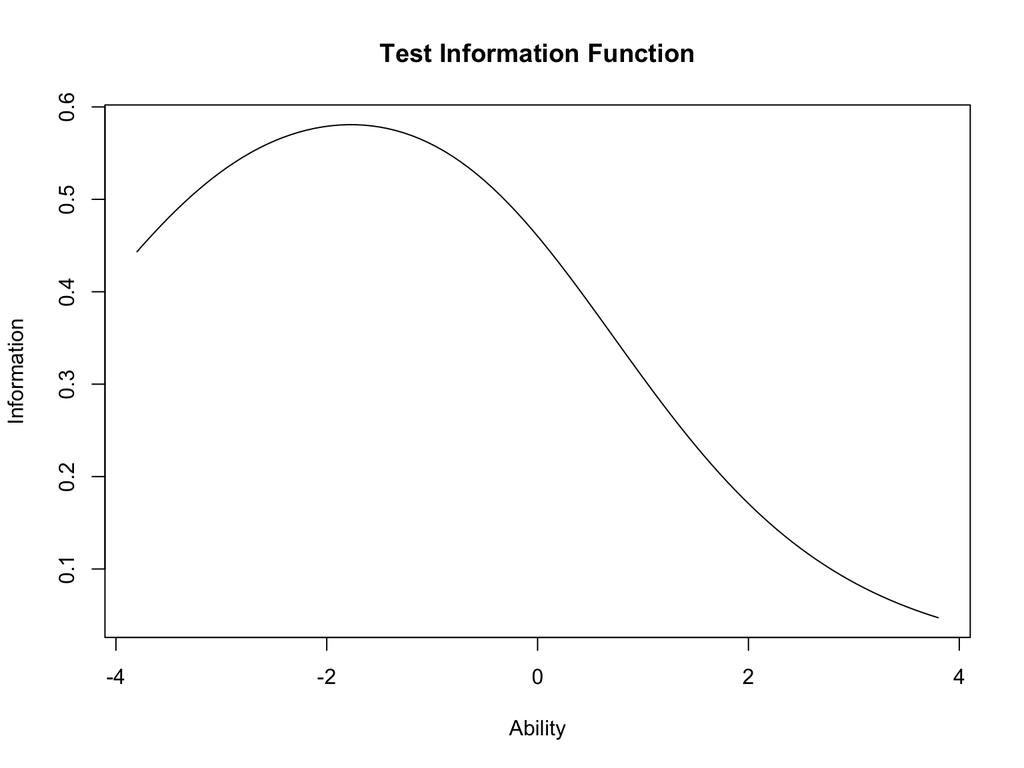

```r
plot(LSAT.model, type = "IIC", items = 0) ## Test Information Function
```

# 2PL Other Options

```r
factor.scores(LSAT.model)
```

```
##
## Call:
## ltm(formula = LSAT ~ z1, IRT.param = TRUE)
##
## Scoring Method: Empirical Bayes
##
## Factor-Scores for observed response patterns:
##    Item 1 Item 2 Item 3 Item 4 Item 5 Obs     Exp     z1 se.z1
## 1       0      0      0      0      0   3   2.277 -1.895 0.795
## 2       0      0      0      0      1   6   5.861 -1.479 0.796
## 3       0      0      0      1      0   2   2.596 -1.460 0.796
## 4       0      0      0      1      1  11   8.942 -1.041 0.800
## 5       0      0      1      0      0   1   0.696 -1.331 0.797
## 6       0      0      1      0      1   1   2.614 -0.911 0.802
## 7       0      0      1      1      0   3   1.179 -0.891 0.803
```

[output cut: 23 more lines]

# Three Parameter Logistic

```r
LSAT.model2 <- tpm(LSAT, #dataset
                   type = "latent.trait",
                   IRT.param = TRUE)
```

# 3PL Output

- Difficulty = b = theta = ability
- Discrimination = a = how good the question is at figuring a person out.
- Guessing = c = how easy the item is to guess

```r
coef(LSAT.model2)
```

```
##            Gussng     Dffclt    Dscrmn
## Item 1 0.03738668 -3.2964761 0.8286287
## Item 2 0.07770995 -1.1451487 0.7603748
## Item 3 0.01178206 -0.2490144 0.9015777
## Item 4 0.03529306 -1.7657862 0.7006545
## Item 5 0.05315665 -2.9902046 0.6657969
```

# 3PL Plots

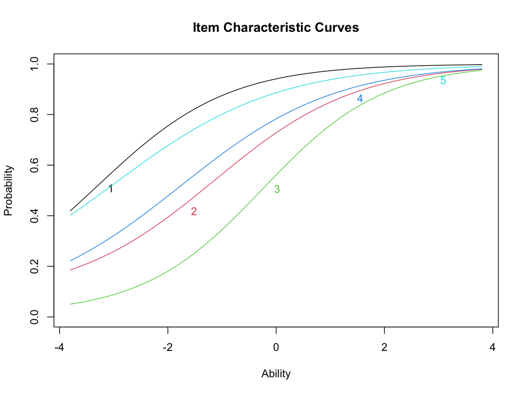

```r
plot(LSAT.model2, type = "ICC") ## all items at once
```

# 3PL Plots

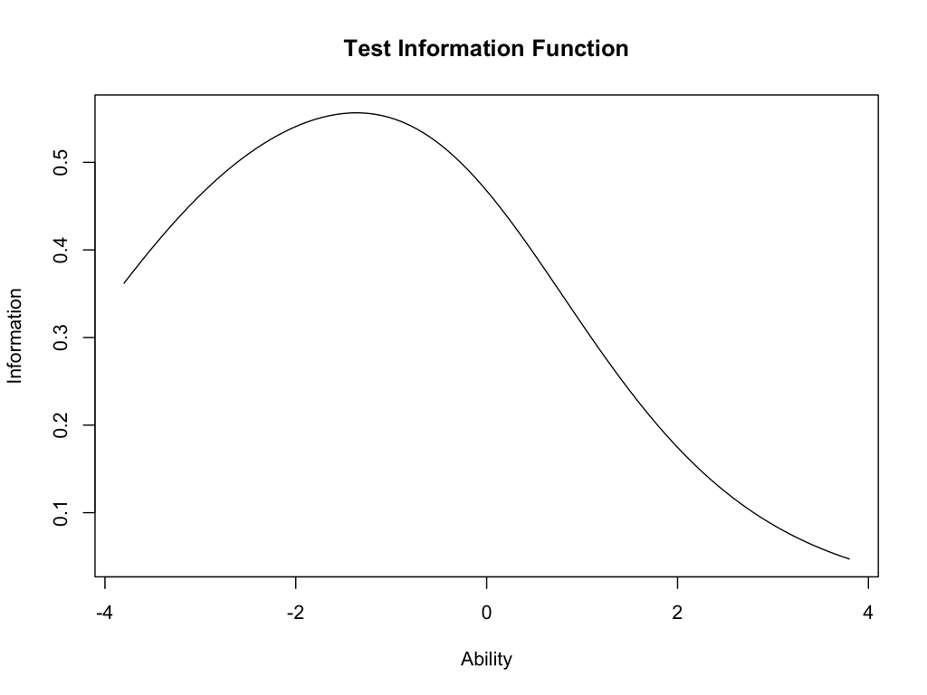

```r
plot(LSAT.model2, type = "IIC", items = 0) ## Test Information Function
```

# 3PL Other Options

```r
factor.scores(LSAT.model2)
```

```
##
## Call:
## tpm(data = LSAT, type = "latent.trait", IRT.param = TRUE)
##
## Scoring Method: Empirical Bayes
##
## Factor-Scores for observed response patterns:
##    Item 1 Item 2 Item 3 Item 4 Item 5 Obs     Exp     z1 se.z1
## 1       0      0      0      0      0   3   2.230 -1.871 0.790
## 2       0      0      0      0      1   6   5.820 -1.463 0.792
## 3       0      0      0      1      0   2   2.583 -1.446 0.793
## 4       0      0      0      1      1  11   8.944 -1.032 0.796
## 5       0      0      1      0      0   1   0.701 -1.325 0.796
## 6       0      0      1      0      1   1   2.628 -0.908 0.800
## 7       0      0      1      1      0   3   1.185 -0.889 0.801
```

[output cut: 23 more lines]

# Compare Models

```r
anova(LSAT.model, LSAT.model2)
```

```
##
##  Likelihood Ratio Table
##                 AIC     BIC  log.Lik   LRT df p.value
## LSAT.model  4953.31 5002.38 -2466.65
## LSAT.model2 4963.32 5036.94 -2466.66 -0.01  5       1
```

# Polytomous IRT

- Dataset includes the Meaning in Life Questionnaire

```r
library(rio)
poly.data <- import("lecture_irt.csv")
poly.data <- na.omit(poly.data)

#reverse code
poly.data$Q99_9 = 8 - poly.data$Q99_9

#separate factors
poly.data1 = poly.data[ , c(1, 4, 5, 6, 9)]
poly.data2 = poly.data[ , c(2, 3, 7, 8, 10)]
```

# Graded Partial Credit Model

```r
gpcm.model1 <- mirt(data = poly.data1, #data
                    model = 1, #number of factors
                    itemtype = "gpcm") #poly model type
```

[output not shown]

[output cut: 19 more lines]

[output not shown]

# GPCM Output

- Can also get factor loadings here, with standardized coefficients to help us determine if they relate to their latent trait

```r
summary(gpcm.model1) ##standardized coefficients
```

```
##          F1     h2
## Q99_1 0.749 0.5608
## Q99_4 0.865 0.7490
## Q99_5 0.815 0.6642
## Q99_6 0.821 0.6737
## Q99_9 0.309 0.0955
##
## SS loadings:  2.743
## Proportion Var:  0.549
##
## Factor correlations:
##
##    F1
## F1  1
```

# GPCM Output

```r
coef(gpcm.model1, IRTpars = T) ##coefficients
```

```
## $Q99_1
##         a     b1     b2     b3     b4    b5    b6
## par 1.923 -1.903 -1.343 -1.107 -0.607 0.226 1.236
##
## $Q99_4
##        a     b1    b2     b3     b4    b5    b6
## par 2.94 -1.951 -1.67 -1.082 -0.592 0.121 0.973
##
## $Q99_5
##         a    b1     b2     b3     b4     b5   b6
## par 2.394 -2.05 -1.601 -1.255 -0.825 -0.093 0.98
##
## $Q99_6
##         a     b1     b2     b3     b4    b5    b6
## par 2.446 -2.012 -1.429 -1.167 -0.531 0.118 1.086
##
## $Q99_9
##         a     b1     b2     b3     b4     b5     b6
## par 0.553 -1.671 -2.489 -1.202 -0.113 -1.115 -0.295
##
## $GroupPars
##     MEAN_1 COV_11
## par      0      1
```

```r
head(fscores(gpcm.model1)) ##factor scores
```

```
##              F1
## [1,] -0.6798876
## [2,] -2.7474343
## [3,] -1.2481220
## [4,] -1.4220622
## [5,] -2.7474343
## [6,] -2.7474343
```

# GPCM Plots

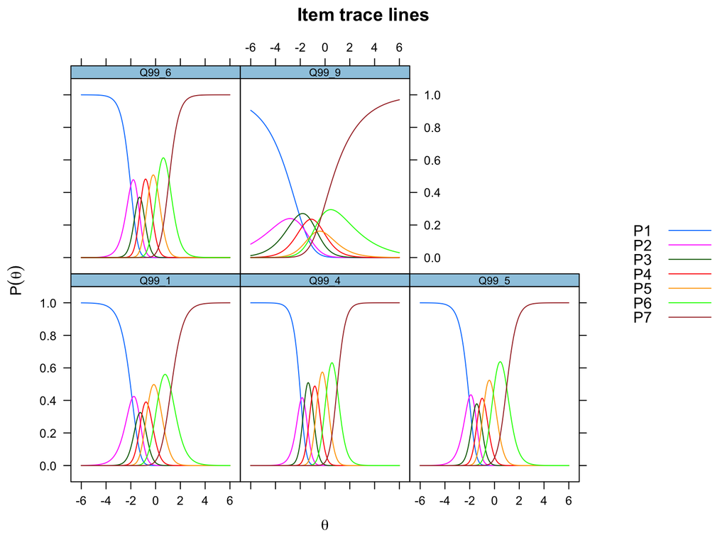

```r
plot(gpcm.model1, type = "trace") ##curves for all items at once
```

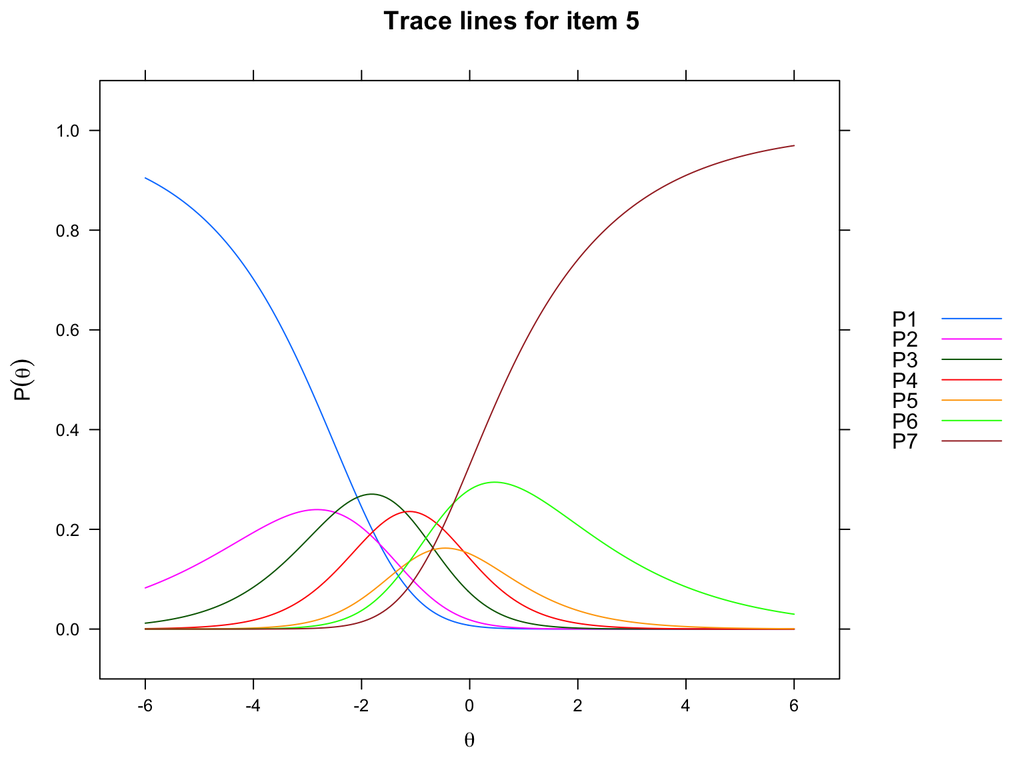

```r
itemplot(gpcm.model1, 5, type = "trace")
```

# GPCM Plots

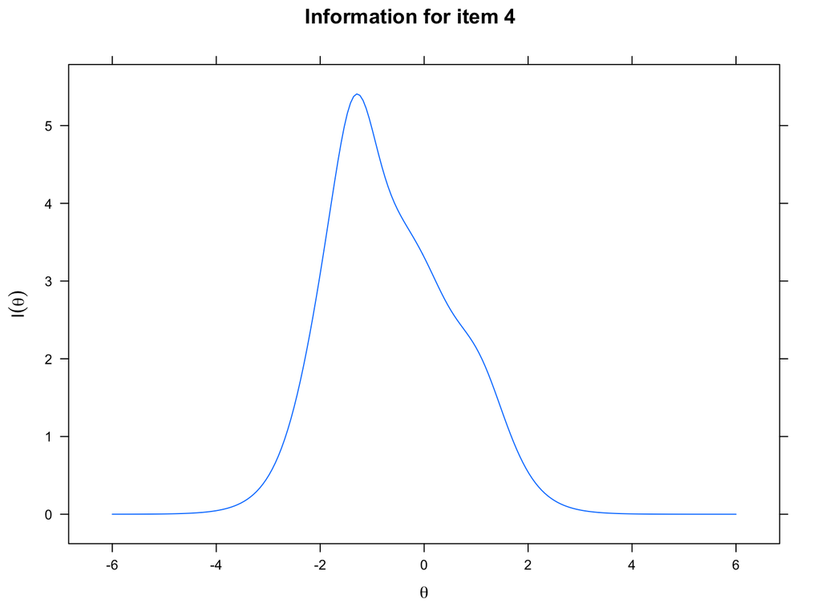

```r
itemplot(gpcm.model1, 4, type = "info") ##IIC for each item
```

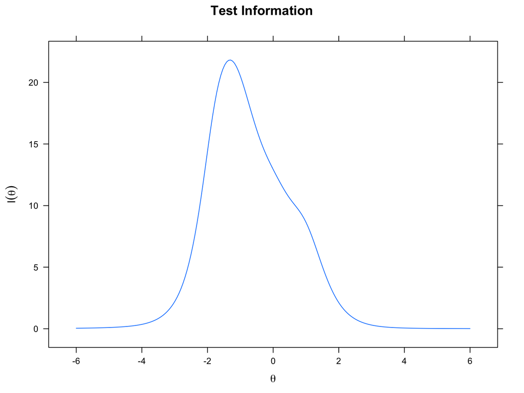

```r
plot(gpcm.model1, type = "info") ##test information curve
```

# GPCM Plots

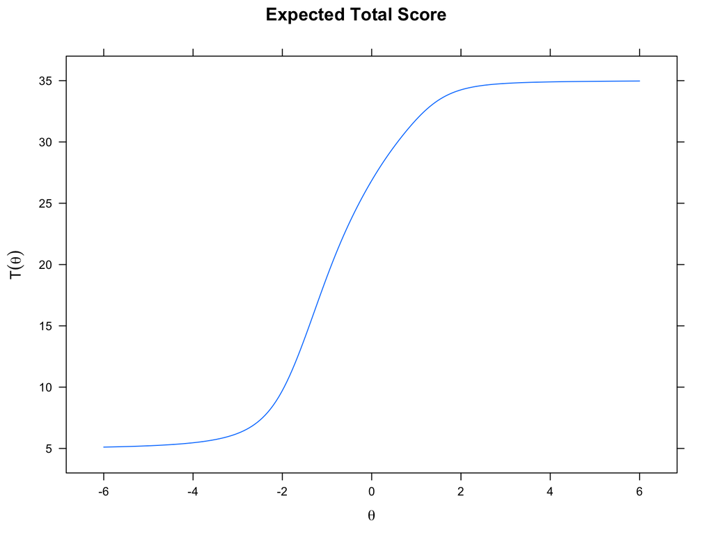

```r
plot(gpcm.model1) ##expected score curve
```

# Summary

- In this lecture you’ve learned:
  - Item response theory compared to classical test theory
  - How to run a dichotomous or traditional IRT with 2PL and 3PL
  - How to run a polytomous IRT using graded partial credit model
  - How to compare models and interpret their output